# Spline models vs. no RIN term

## Spline models vs. no RIN term

First download the Ballgown package and load the GEUVADIS FPKM ballgown object. (The file `fpkm.rda` can be downloaded from [this link](http://files.figshare.com/1625419/fpkm.rda))

```r
library(ballgown) #need version 0.99.3 or higher
load('fpkm.rda')
```

Next we subset to unique individuals, noted by the qcstats file and also in the pData component of `fpkm`:

```r
gbg_small = subset(fpkm, "UseThisDup==1", genomesubset=FALSE)
```

Then we subset to highly-expressed transcripts (mean FPKM > 0.1)

```r
gbg = exprfilter(gbg_small, cutoff=0.1, meas='FPKM')
gbg
```

```
## ballgown instance with 43622 transcripts and 464 samples
```

We then run the statistical analysis to determine which transcripts' expression levels are most affected by RIN:

```r
rin_results_hiexpr = stattest(gbg, feature="transcript",
    meas="FPKM", timecourse=TRUE, covariate="RIN", adjustvars="population")
sum(rin_results_hiexpr$qval<0.05)
```

```
## [1] 19203
```

```r
results_sorted = rin_results_hiexpr[order(rin_results_hiexpr$pval),]
```

Next we plot RIN vs. expression for a few transcripts where there seems to be a statistically significant relationship. First we need to manually extract the library-size adjustment used in the models:

```r
libadjust = apply(texpr(gbg), 2, function(x){
    lognz = log2(x[x!=0] + 1)
    q3 = quantile(lognz, 0.75)
    sum(lognz[lognz<q3])
})
```

Then we define a plotting function: x-axis is RIN, y-axis is log expression, and the model fit is drawn separately for each of the five populations in the GEUVADIS dataset, assuming average library size:

```r
plotfitted = function(results, rowInd, bgobj, lib_adj,
    legloc = 'topleft', returnModel = FALSE,
    writecsv = TRUE, fname=NULL, ...){
    require(splines)
    require(RSkittleBrewer)
    tid = as.numeric(as.character(results[rowInd,]$id))
    ind = which(texpr(bgobj,'all')$t_id == tid)
    transexp = log2(texpr(bgobj,"FPKM")[ind,]+1)
    mdf = data.frame(pData(bgobj)$RIN, as.factor(pData(bgobj)$population), as.numeric(transexp), lib_adj)
    mdf = mdf[order(mdf[,1]),]
    names(mdf) = c("RIN", "pop", "expression", "lib")
    model = lm(expression ~ ns(RIN, 4) + pop + lib, data=mdf)
    plot(mdf[,1], mdf[,3], xlab="RIN", ylab="log2(transcript expression + 1)", ...)
    chr = texpr(bgobj,'all')$chr[ind]
    start = texpr(bgobj,'all')$start[ind]
    end = texpr(bgobj,'all')$end[ind]
    title(paste0("transcript ", tid, ", ", chr, ": ",start,"-",end))

    # predictions
    n = nrow(mdf)
    lib = rep(mean(lib_adj), n)
    colpal = RSkittleBrewer('wildberry')
    newdataYRI = data.frame(RIN=mdf[,1], pop=rep("YRI", n), lib)
    newdataCEU = data.frame(RIN=mdf[,1], pop=rep("CEU", n), lib)
    newdataFIN = data.frame(RIN=mdf[,1], pop=rep("FIN", n), lib)
    newdataGBR = data.frame(RIN=mdf[,1], pop=rep("GBR", n), lib)
    newdataTSI = data.frame(RIN=mdf[,1], pop=rep("TSI", n), lib)
    lines(mdf$RIN, predict(model, newdataYRI), col=colpal[1], lwd=3)
    lines(mdf$RIN, predict(model, newdataCEU), col=colpal[2], lwd=3)
    lines(mdf$RIN, predict(model, newdataFIN), col=colpal[3], lwd=3)
    lines(mdf$RIN, predict(model, newdataGBR), col=colpal[4], lwd=3)
    lines(mdf$RIN, predict(model, newdataTSI), col=colpal[5], lwd=3)
    legend(legloc, col=colpal, lwd=3, c("YRI", "CEU", "FIN", "GBR", "TSI"))

    if(writecsv){
        x = rep(mdf$RIN, 6)
        y = c(mdf$expression,
            predict(model, newdataYRI),
            predict(model, newdataCEU),
            predict(model, newdataFIN),
            predict(model, newdataGBR),
            predict(model, newdataTSI))
        type = c(rep('point', nrow(mdf)),
            rep('YRI_line', nrow(newdataYRI)),
            rep('CEU_line', nrow(newdataCEU)),
            rep('FIN_line', nrow(newdataFIN)),
            rep('GBR_line', nrow(newdataGBR)),
            rep('TSI_line', nrow(newdataTSI)))
        df = data.frame(x=x, y=y, type=type)
        write.csv(df, file=fname, row.names=FALSE, quote=FALSE)
    }

    if(returnModel){
        return(model)
    }
}
```

Here are the RIN panels for Figure 1 (Figure 1c-d). Associated data is written to CSV.

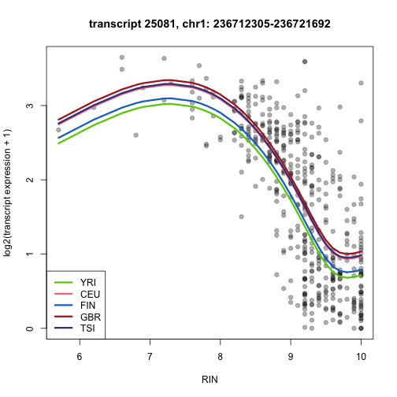

```r
plotfitted(results_sorted, 242, gbg, libadjust, pch=19, col="#00000050", legloc='bottomleft', writecsv=TRUE, fname='1c.csv')
```

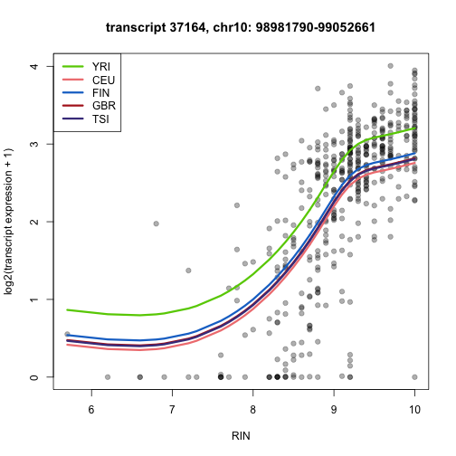

```r
plotfitted(results_sorted, 328, gbg, libadjust, pch=19, col="#00000050", writecsv=TRUE, fname='1d.csv')
```

## Polynomial vs. Linear fit

First we create the design matrices for the polynomial and linear models:

```r
RIN = pData(gbg)$RIN
RIN2 = RIN^2
RIN3 = RIN^3
pop = as.factor(pData(gbg)$population)
modx = model.matrix(~RIN + RIN2 + RIN3 + pop + libadjust)
mod0x = model.matrix(~RIN + pop + libadjust)
```

And then we find the transcripts where the polynomial model fits better:

```r
statres_poly_or_not = stattest(gbg, mod=modx, mod0=mod0x, feature='transcript',
    meas='FPKM')
curvebetter_sort = statres_poly_or_not[order(statres_poly_or_not$pval),]
length(which(curvebetter_sort$qval < 0.05))
```

```
## [1] 1499
```

The result from the transcript in Figure 1c is:

```r
curvebetter_sort[which(curvebetter_sort$id == 25081),]$qval
```

```
## [1] 3.188239e-06
```

And the result from the transcript in Figure 1d is:

```r
curvebetter_sort[which(curvebetter_sort$id == 37164),]$qval
```

```
## [1] 0.0001830679
```

Both show that the polynomial fit is significantly better than the linear fit.

## Distribution of RIN effects

Next, we investigate the distribution of RIN effects: if a transcript's expression measurement is affected by RIN (RNA quality), the relationship is more likely to be positive than negative, i.e., it makes more sense that better RNA quality means higher transcript expression measurements. To investigate this, we'll make a histogram of empirical Bayes (shrunk) t-statistics for the estimated linear RIN coefficients for each transcript (Supplementary Figure 8):

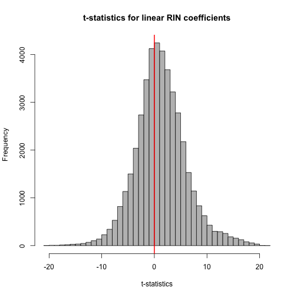

```r
library(limma)
x = model.matrix(~as.factor(pData(gbg)$population) + pData(gbg)$RIN)
y = log2(texpr(gbg)+1)
model = lmFit(y, x)
ebmodel = eBayes(model, trend=TRUE)
hist(ebmodel$t[,6], col='gray', main='t-statistics for linear RIN coefficients', xlab='t-statistics', breaks=50)
abline(v=0, col='red', lwd=2)
```

As expected, the distribution of t-statistics is shifted toward positive statistics (rather than centered around 0), with a mean of 1.2768931.

## Coverage vs. FPKM

Finally, we'll repeat the RIN analysis using average coverage instead of FPKM as the expression measurement. We will need another Ballgown object for this, available [here](http://files.figshare.com/1625417/cov.rda). This code makes Supplementary Figure 7c. Transcripts are downsampled to make the plot somewhat readable.

```r
load('cov.rda')
cov_small = subset(cov, "UseThisDup==1", genomesubset=FALSE)
# test the same highly-expressed transcripts from before
cov_filt = subset(cov_small, "t_id %in% rin_results_hiexpr$id")
rrcov = stattest(cov_filt, feature="transcript", meas="cov",
    timecourse=TRUE, covariate="RIN", adjustvars="population")
sum(as.character(rrcov$id) != as.character(rin_results_hiexpr$id)) # expect 0 (sanity check)
```

```
## [1] 0
```

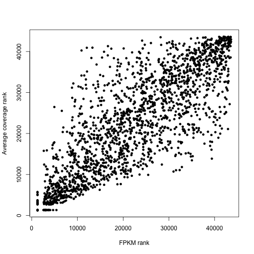

```r
fpkmrank = rank(rin_results_hiexpr$pval)
covrank = rank(rrcov$pval)
set.seed(12390)
inds = sample(1:length(fpkmrank), 2000) # downsampling, for readability
plot(fpkmrank[inds], covrank[inds], xlab="FPKM rank", ylab="Average coverage rank", pch=19, cex=0.7)
```

```r
cor(fpkmrank[inds], covrank[inds])
```

```
## [1] 0.8359326
```